# atoms_crystals_electrons_problem slides

## Day 2 - Morning Session

**Outline**

- atoms and crystal structure
- how electron's behave
- the Schrödinger equation
- the problem...

## atoms and crystal structure

```julia
img = load("../../img/periodic_table.png")
plot(img,grid=false, axis=nothing, showaxis=false)
```

[output not shown]

**brief basics of periodic table**

- increasing the number of protons (electrons)
- structure: nucleus (protons and neutrons) and electrons
- all of life (C, H, N, O, S, P)

**How are elements made?**

**What do they look like?**

```julia
function circle(x, y, r)
    θ = LinRange(0, 2*π, 500)
    x .+ r*sin.(θ), y .+ r*cos.(θ)
end;

n=100;
anim = @animate for i ∈ 1:n
    r = 0.05
    p = plot(circle(0,0,1.1), seriestype=[:shape], lw=1, legend=false, axis=nothing, grid=false, c=:white, linecolor=:black, aspect_ratio=1);
    plot!(p, circle(0,0,0.9), seriestype=[:shape], lw=1, legend=false, axis=nothing, grid=false, c=:white, linecolor=:black, aspect_ratio=1);
    plot!(p, circle(0,0,0.7), seriestype=[:shape], lw=1, legend=false, axis=nothing, grid=false, c=:white, linecolor=:black, aspect_ratio=1);
    plot!(p, circle(0,0,0.1), seriestype=[:shape], lw=0, legend=false, axis=nothing, grid=false, c=:red, linecolor=:red, fillalpha=0.5, aspect_ratio=1);
    plot!(p, title="Cartoon of hydrogen", showaxis=false);
    annotate!(p, 0, 0.2, "Z=1");
    x = cos(2π*i/n)
    y = sin(2π*i/n)
    plot!(p, circle(-x*0.7,y*0.7,r), seriestype=[:shape], lw=0, c=:blue, fillalpha=0.75)
end;
```

```
┌ Info: Saved animation to
│   fn = /Users/harrisonlabollita/botana_group/outreach/CdeAz2021/day2/slides/hydrogen.gif
└ @ Plots /Users/harrisonlabollita/.julia/packages/Plots/6EMd6/src/animation.jl:104
```

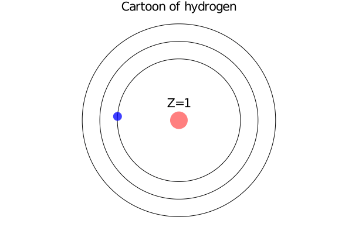

```julia
gif(anim, "hydrogen.gif", fps=20)
```

### but not quite

This picture isn't quite right...

```julia
using PyPlot

u = range(0,stop=2*π,length=n);
v = range(0,stop=π,length=n);

x = cos.(u) * sin.(v)';
y = sin.(u) * sin.(v)';
z = ones(n) * cos.(v)';
p = plot(x,y,z, rstride=4, cstride=4, alpha=0.25, color = "blue", showaxis=false)
r = 0.2
x = r * cos.(u) * sin.(v)';
y = r * sin.(u) * sin.(v)';
z = r * ones(n) * cos.(v)';
plot!(p, x,y,z, rstride=4, cstride=4, alpha=1, color = "red", showaxis=false)
plot!(p, aspect_ratio=0.75, legend=false, showaxis=false, grid=false, xticks=[], yticks=[],zticks=[]);
```

```
WARNING: using PyPlot.plot in module Main conflicts with an existing identifier.
```

```julia
plot!(p, title="Realistic Hydrogen atom")
```

[figure not shown]

```julia
img = load("../../img/electron_orbitals.jpg")
plot(img,grid=false, axis=nothing, showaxis=false)
```

[output not shown]

The electron can be anywhere in the cloud, but what's the scale..?

```julia
# If the proton where a tennis ball...
proton = 0.8e-15 # m
electron_cloud = 0.5e-10 # m
scale = electron_cloud/proton
tennis_ball = 6.86e-2 # m
println("The size of the electron cloud at tennis ball scale is $(round(scale*tennis_ball/1000)) km or $(round(scale*tennis_ball/1000*0.621371)) mi.")
```

```
The size of the electron cloud at tennis ball scale is 4.0 km or 3.0 mi.
```

## how electron's behave

```julia
# mass
electron_mass = 9e-31 #kg
proton_mass = 1.6e-27 #kg
println("proton mass / electron mass = $(round(proton_mass/electron_mass))")
```

```
proton mass / electron mass = 1778.0
```

### cans and can'ts

- the electrons can exist in only certain shells (quantum)
- can't be labelled: no red and blue or 1 and 2. Electrons are indistinguishable! (quantum)
- charge (**opposites attact** and **likes repel**) (classical)
- spin (quantum)
- no two electrons can exist in the exact same spot! (quantum)
- also, we can't ever really know where the electrons are! (quantum)

## How do we get a solid?

Electrons don't want to be together, but also are the glue that holds everything together!

- Metallic bonding
- Covalent bonding
- Ionic bonding
- and more...

### Metallic Bonding 🍜

All of the atoms share each other's electrons. Electron soup

### Covalent Bonding 🤝

Strong overlap between the electron orbitals on neighboring atoms

### Ionic bonding ☯️

One atomic species gives up their electrons and another atomic species takes these electrons

## the Schrödinger equation

[Erwin Schrödinger](https://en.wikipedia.org/wiki/Erwin_Schrödinger) wrote down the equation

$$ H\psi = E \psi $$

For a generic solid,

$$ \Bigg (-\sum_{i} \frac{ \hbar^{2}}{2m_{e}} \nabla^{2}_{\vec{r}_{i}} - \sum_{I}\frac{Z_{I}e^{2}}{|\vec{R}_{I} - \vec{r}_{i}|} + \frac{e^{2}}{2} \sum_{i\neq j} \frac{1}{|\vec{r}_{i} - \vec{r}_{j}|} + \mathcal{H}^{\text{ion}} \Bigg ) \psi = E \psi$$

Without holding back, this is essentially the equations that we need to solve. We can solve this for the hydrogen atom, but that's about it...

## the problem...

Say we only want to keep track of the spin of N electrons. Their spin can be either up or down.

We have to keep track of all of the possible configurations

```julia
spins = 2                   # up and down
N     = collect(1:5:100)    # number of electons
for num ∈ N
    sleep(1)
    println("num e: $(num)  possible configs $(spins^num)")
    sleep(1)
end
```

```
num e: 1  possible configs 2
num e: 6  possible configs 64
num e: 11  possible configs 2048
num e: 16  possible configs 65536
num e: 21  possible configs 2097152
num e: 26  possible configs 67108864
num e: 31  possible configs 2147483648
num e: 36  possible configs 68719476736
num e: 41  possible configs 2199023255552
num e: 46  possible configs 70368744177664
num e: 51  possible configs 2251799813685248
num e: 56  possible configs 72057594037927936
num e: 61  possible configs 2305843009213693952
num e: 66  possible configs 0
num e: 71  possible configs 0
num e: 76  possible configs 0
num e: 81  possible configs 0
num e: 86  possible configs 0
num e: 91  possible configs 0
num e: 96  possible configs 0
```

We need to keep track of $10^{23}$ electrons!

```julia
println("If we had 1e23 dollar bills...")
sleep(2)
println("1 dollar bill is $(6.14*1/12) feet...")
sleep(2)
println("1e23 dollar bills would be $((6.14*1e23*(1/12))/5280) miles...")
sleep(2)
println("The sun is 95 million miles...")
sleep(2)
println("We could go to the sun and back $((6.14*1e23*(1/12))/5280/(2*95e6)) times!")
```

```
If we had 1e23 dollar bills...
1 dollar bill is 0.5116666666666666 feet...
1e23 dollar bills would be 9.690656565656564e18 miles...
The sun is 95 million miles...
We could go to the sun and back 5.100345560871876e10 times!
```

```julia
system(N) = rand(N, N)
memory(N) = @time(system(N))
memory(50000);
```

```
 27.947324 seconds (2 allocations: 18.626 GiB, 0.16% gc time)
```

## So what are we going to do...

We make approximations...this leads us to density functional theory!